# Defense Services Ceiling Breaches

Greg Sanders, Justin Graham

Friday July 13, 2019

# Modeling Likelihood or size of Ceiling Breach

# Setup

## Load Data

First we load the data. The dataset used is a U.S. Defense Contracting dataset derived from FPDS.

```r
load(file="..//data//clean//def_sample.Rdata")
```

The sample is created by including the entirity of the ARRA and Disaster datasets, as well as 100,000 records each from the OCO datase and another 100,000 from all remaining records.

# Study Variables

## Services Complexity

Expectation: Higher service complexity would make work more demanding and thus raises the risks of negative contracting outcomes, namely the likelihood of cost ceiling breaches and terminations increases and the likelihood exercised options decraeses.

### 01A NAICS Salary

Expectation: Given the fact that one source for higher salaries is the difficulty of the work and the experience and education required, as average NAICS salary increases (decreases), the likelihood of cost ceiling breaches and terminations increases (decreases) and exercised options decreases (increases). We also then expect that higher average NAICS salaries (lower) will be correlated with ceiling breaches larger (smaller) in absolute size.

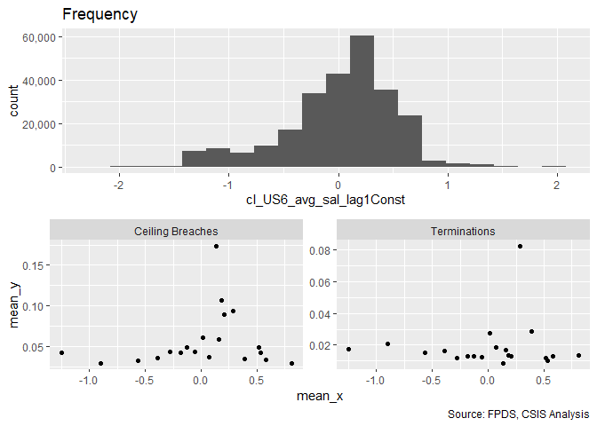

```r
 # !is.na(def_serv$cl_US6_avg_sal_lag1)&
 #  !is.na(def_serv$cl_CFTE)&
 #  !is.na(def_serv$c_pPBSC)&
 #  !is.na(def_serv$c_pOffPSC)&
 #  !is.na(def_serv$c_pairHist)&
 #  !is.na(def_serv$cl_pairCA)&

summary_continuous_plot(serv_smp,"cl_US6_avg_sal_lag1Const")
```

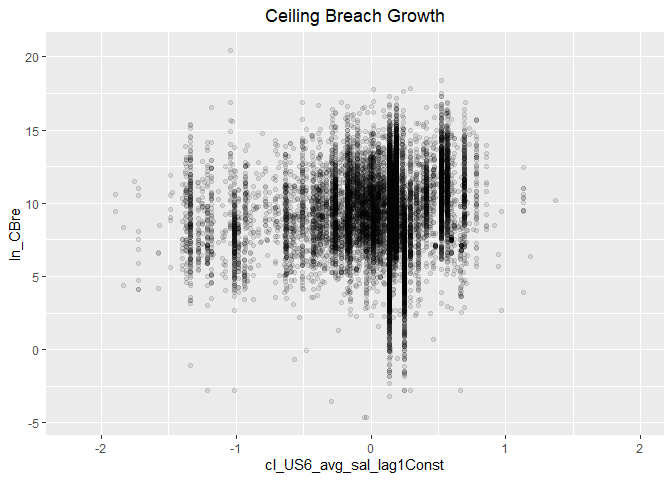

```r
#Scatter Plot of n_CBre01A
ggplot(serv_smp, aes(x=cl_US6_avg_sal_lag1Const, y=ln_CBre)) + geom_point(alpha = 0.1) + ggtitle('Ceiling Breach Growth') + theme(plot.title = element_text(hjust = 0.5))
```

```r
#Model
b_CBre01A <- glm (data=serv_smp,
                 b_CBre ~ cl_US6_avg_sal_lag1Const, family=binomial(link="logit"))
display(b_CBre01A)
```

```
## glm(formula = b_CBre ~ cl_US6_avg_sal_lag1Const, family = binomial(link = "logit"),
##     data = serv_smp)
##                          coef.est coef.se
## (Intercept)              -2.82     0.01
## cl_US6_avg_sal_lag1Const  0.21     0.02
## ---
##   n = 250000, k = 2
##   residual deviance = 108224.2, null deviance = 108365.4 (difference = 141.1)
```

```r
n_CBre01A <- glm(data=serv_smp,
                        ln_CBre ~ cl_US6_avg_sal_lag1Const)
display(n_CBre01A)
```

```
## glm(formula = ln_CBre ~ cl_US6_avg_sal_lag1Const, data = serv_smp)
##                          coef.est coef.se
## (Intercept)              9.21     0.02
## cl_US6_avg_sal_lag1Const 0.78     0.06
## ---
##   n = 15018, k = 2
##   residual deviance = 113042.1, null deviance = 114568.9 (difference = 1526.7)
##   overdispersion parameter = 7.5
##   residual sd is sqrt(overdispersion) = 2.74
```

```r
#Plot residuals versus fitted
stargazer::stargazer(b_CBre01A,n_CBre01A,type="text",
                       digits=2)
```

```
##
## =====================================================
##                              Dependent variable:
##                          ----------------------------
##                              b_CBre        ln_CBre
##                             logistic       normal
##                               (1)            (2)
## -----------------------------------------------------
## cl_US6_avg_sal_lag1Const    0.21***        0.78***
##                              (0.02)        (0.06)
##
## Constant                    -2.82***       9.21***
##                              (0.01)        (0.02)
##
## -----------------------------------------------------
## Observations                250,000        15,018
## Log Likelihood             -54,112.11    -36,467.62
## Akaike Inf. Crit.          108,228.20     72,939.24
## =====================================================
## Note:                     *p<0.1; **p<0.05; ***p<0.01
```

Individually, expectations are matched for ceiing breaches, as higher average salaries estimate a higher risk of ceiling breaches. In our GLM, we find an analogous relationship to our logit model, with higher salaries correlated with ceiling breaches of larger magnitudes.

### 01B Invoice Rate

Expectation: The invoice rate approximates how much the government is charged annually for each comparable full-time employees who are supporting the service contracts. A higher invoice rate indicates a more complex service. As invoice rate increases (decreases), the likelihood of cost ceiling breaches and terminations increases (decreases), and exercised options decrease (increase). Likewise, we expect a higher invoice rate (lower) to be associated with ceiling breaches larger (smaller) in absolute magnitude.

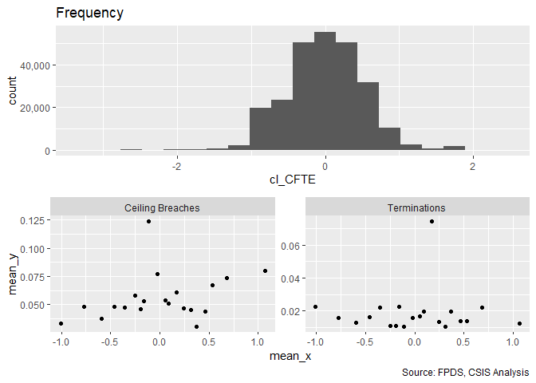

```r
 # !is.na(def_serv$cl_US6_avg_sal_lag1)&
 #  !is.na(def_serv$cl_CFTE)&
 #  !is.na(def_serv$c_pPBSC)&
 #  !is.na(def_serv$c_pOffPSC)&
 #  !is.na(def_serv$c_pairHist)&
 #  !is.na(def_serv$cl_pairCA)&

summary_continuous_plot(serv_smp,"cl_CFTE")
```

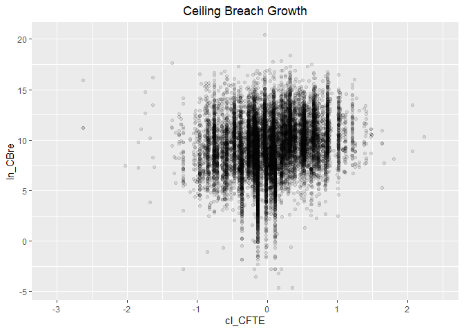

```r
#Scatter Plot
ggplot(serv_smp, aes(x=cl_CFTE, y=ln_CBre)) + geom_point(alpha = 0.1) + ggtitle('Ceiling Breach Growth') + theme(plot.title = element_text(hjust = 0.5))
```

```r
#Model
b_CBre01B <- glm (data=serv_smp,
                 b_CBre ~ cl_CFTE, family=binomial(link="logit"))
display(b_CBre01B)
```

```
## glm(formula = b_CBre ~ cl_CFTE, family = binomial(link = "logit"),
##     data = serv_smp)
##             coef.est coef.se
## (Intercept) -2.82     0.01
## cl_CFTE      0.19     0.02
## ---
##   n = 250000, k = 2
##   residual deviance = 108244.1, null deviance = 108365.4 (difference = 121.2)
```

```r
n_CBre01B <- glm(data=serv_smp,
                        ln_CBre ~ cl_CFTE)



#Plot residuals versus fitted
  stargazer::stargazer(b_CBre01A,b_CBre01B,

                       n_CBre01A,n_CBre01B,
                       type="text",
                       digits=2)
```

```
##
## ====================================================================
##                                      Dependent variable:
##                          -------------------------------------------
##                                 b_CBre                ln_CBre
##                                logistic               normal
##                             (1)        (2)        (3)        (4)
## --------------------------------------------------------------------
## cl_US6_avg_sal_lag1Const  0.21***               0.78***
##                            (0.02)                (0.06)
##
## cl_CFTE                              0.19***               1.20***
##                                       (0.02)                (0.05)
##
## Constant                  -2.82***   -2.82***   9.21***    9.20***
##                            (0.01)     (0.01)     (0.02)     (0.02)
##
## --------------------------------------------------------------------
## Observations              250,000    250,000     15,018     15,018
## Log Likelihood           -54,112.11 -54,122.07 -36,467.62 -36,251.56
## Akaike Inf. Crit.        108,228.20 108,248.10 72,939.24  72,507.12
## ====================================================================
## Note:                                    *p<0.1; **p<0.05; ***p<0.01
```

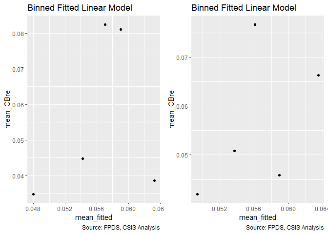

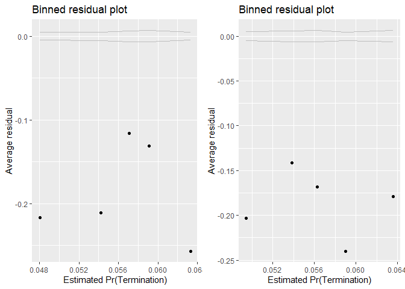

```r
summary_residual_compare(b_CBre01A,b_CBre01B, skip_vif = TRUE)
```

When considered alone, expectations are matched for ceiling breaches, as higher invoice rate estimates a higher risk of ceiling breaches and lower possibility of exercised options. Similarly, higher invoice rates are correlated with larger ceiling breaches, matching our expectations.

### 01C Service Complexity

Expectation: Collectively, the higher average salary and invoice rate (more complexity is indicated), the higher risk of ceiling breaches and terminations and the less exercised options there would be. Also, we expect the result of combined model would be the same as individual models. Again, we expect higher levels of complexity to be correlated with larger ceiling breaches.

```r
 #  !is.na(def_serv$c_pPBSC)&
 #  !is.na(def_serv$c_pOffPSC)&
 #  !is.na(def_serv$c_pairHist)&
 #  !is.na(def_serv$cl_pairCA)&


#Model
b_CBre01C <- glm (data=serv_smp,
                 b_CBre ~ cl_US6_avg_sal_lag1Const + cl_CFTE, family=binomial(link="logit"))
glmer_examine(b_CBre01C)
```

```
## cl_US6_avg_sal_lag1Const                  cl_CFTE
##                 1.144204                 1.144204
```

```r
n_CBre01C <- glm(data=serv_smp,
                        ln_CBre ~ cl_US6_avg_sal_lag1Const +  cl_CFTE)

glmer_examine(n_CBre01C)
```

```
## cl_US6_avg_sal_lag1Const                  cl_CFTE
##                 1.170288                 1.170288
```

```r
#Plot residuals versus fitted
stargazer::stargazer(b_CBre01A,b_CBre01B,b_CBre01C,

                       n_CBre01A,n_CBre01B,n_CBre01C,
                       type="text",
                       digits=2)
```

```
##
## ==========================================================================================
##                                                 Dependent variable:
##                          -----------------------------------------------------------------
##                                       b_CBre                          ln_CBre
##                                      logistic                          normal
##                             (1)        (2)        (3)        (4)        (5)        (6)
## ------------------------------------------------------------------------------------------
## cl_US6_avg_sal_lag1Const  0.21***               0.16***    0.78***               0.30***
##                            (0.02)                (0.02)     (0.06)                (0.06)
##
## cl_CFTE                              0.19***    0.13***               1.20***    1.10***
##                                       (0.02)     (0.02)                (0.05)     (0.05)
##
## Constant                  -2.82***   -2.82***   -2.83***   9.21***    9.20***    9.19***
##                            (0.01)     (0.01)     (0.01)     (0.02)     (0.02)     (0.02)
##
## ------------------------------------------------------------------------------------------
## Observations              250,000    250,000    250,000     15,018     15,018     15,018
## Log Likelihood           -54,112.11 -54,122.07 -54,086.50 -36,467.62 -36,251.56 -36,238.38
## Akaike Inf. Crit.        108,228.20 108,248.10 108,179.00 72,939.24  72,507.12  72,482.76
## ==========================================================================================
## Note:                                                          *p<0.1; **p<0.05; ***p<0.01
```

```r
  summary_residual_compare(b_CBre01A,b_CBre01C)
```

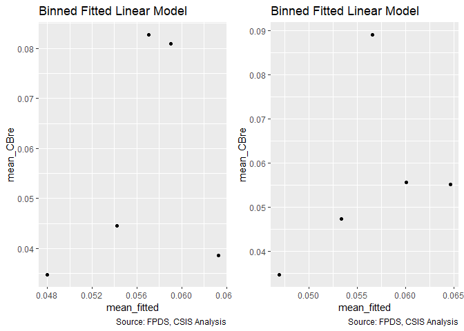

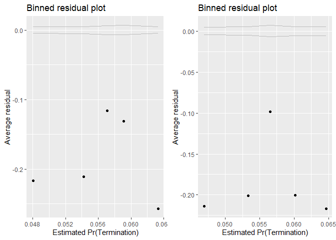

```
## [[1]]
##        model deviance null.deviance difference
## 1 model1_old 108224.2      108365.4   141.1360
## 2 model1_new 108173.0      108365.4   192.3502
##
## [[2]]
## cl_US6_avg_sal_lag1Const                  cl_CFTE
##                 1.144204                 1.144204
```

```r
  summary_residual_compare(b_CBre01B,b_CBre01C)
```

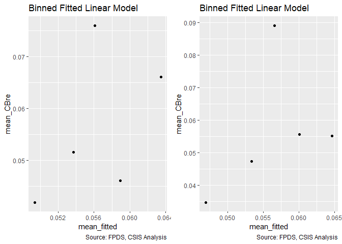

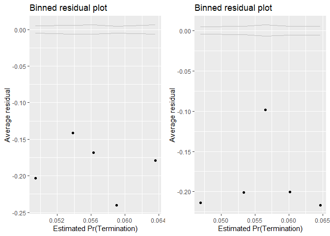

```
## [[1]]
##        model deviance null.deviance difference
## 1 model1_old 108244.1      108365.4   121.2284
## 2 model1_new 108173.0      108365.4   192.3502
##
## [[2]]
## cl_US6_avg_sal_lag1Const                  cl_CFTE
##                 1.144204                 1.144204
```

Both average salary and invoiced rate have a not inconsiderable VIF but one well within bounds, suggesting that the variance of the estimated coefficients is not evidently inflated and none of them are highly correlated with each other.

Both individually and pair-wise, higher average salary and invoiced rate estimate higher possibility of cost ceiling breaches. Likewise, both individually and pair-wise, higher average salary and invoiced rate are correlated with larger ceiling breaches.

## Office Capacity

### 02A: Performance Based Services

Expectation: Performance-based services contracting ties a portion of a contractor’s payment, contract extensions, or contract renewals to the achievement of specific, measurable performance standards and requirements, which encourages better contracting results. PBSC has the potential to reduce terminations and ceiling breaches and bring more possibility of exercised options.

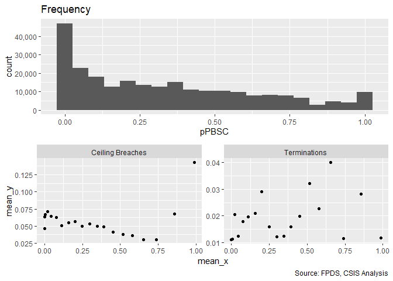

```r
summary_continuous_plot(serv_smp,"pPBSC")
```

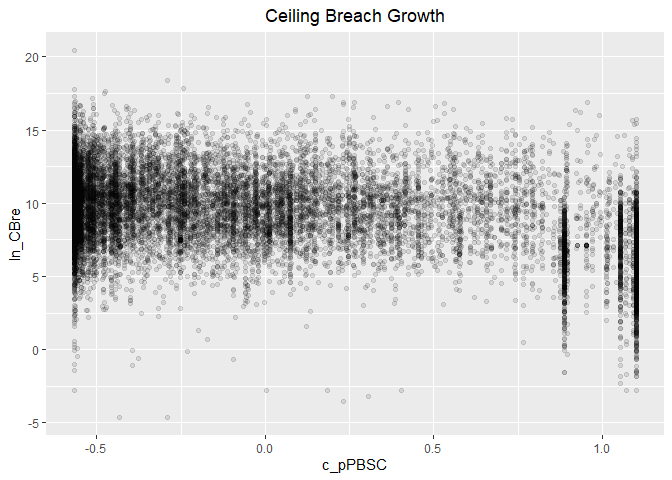

```r
#Scatter Plot
ggplot(serv_smp, aes(x=c_pPBSC, y=ln_CBre)) + geom_point(alpha = 0.1) + ggtitle('Ceiling Breach Growth') + theme(plot.title = element_text(hjust = 0.5))
```

```r
#Model
b_CBre02A <- glm (data=serv_smp,
                 b_CBre ~ c_pPBSC, family=binomial(link="logit"))
display(b_CBre02A)
```

```
## glm(formula = b_CBre ~ c_pPBSC, family = binomial(link = "logit"),
##     data = serv_smp)
##             coef.est coef.se
## (Intercept) -2.82     0.01
## c_pPBSC      0.15     0.02
## ---
##   n = 250000, k = 2
##   residual deviance = 108284.8, null deviance = 108365.4 (difference = 80.6)
```

```r
n_CBre02A <- glm(data=serv_smp,
                        ln_CBre ~ c_pPBSC)

display(n_CBre02A)
```

```
## glm(formula = ln_CBre ~ c_pPBSC, data = serv_smp)
##             coef.est coef.se
## (Intercept)  9.33     0.02
## c_pPBSC     -1.90     0.04
## ---
##   n = 15018, k = 2
##   residual deviance = 96041.7, null deviance = 114568.9 (difference = 18527.2)
##   overdispersion parameter = 6.4
##   residual sd is sqrt(overdispersion) = 2.53
```

```r
#Plot residuals versus fitted
stargazer::stargazer(b_CBre01C,b_CBre02A,
                       n_CBre01C,n_CBre02A,
                       type="text",
                       digits=2)
```

```
##
## ====================================================================
##                                      Dependent variable:
##                          -------------------------------------------
##                                 b_CBre                ln_CBre
##                                logistic               normal
##                             (1)        (2)        (3)        (4)
## --------------------------------------------------------------------
## cl_US6_avg_sal_lag1Const  0.16***               0.30***
##                            (0.02)                (0.06)
##
## cl_CFTE                   0.13***               1.10***
##                            (0.02)                (0.05)
##
## c_pPBSC                              0.15***               -1.90***
##                                       (0.02)                (0.04)
##
## Constant                  -2.83***   -2.82***   9.19***    9.33***
##                            (0.01)     (0.01)     (0.02)     (0.02)
##
## --------------------------------------------------------------------
## Observations              250,000    250,000     15,018     15,018
## Log Likelihood           -54,086.50 -54,142.39 -36,238.38 -35,243.81
## Akaike Inf. Crit.        108,179.00 108,288.80 72,482.76  70,491.63
## ====================================================================
## Note:                                    *p<0.1; **p<0.05; ***p<0.01
```

### 02B: No.Office PSC History

Expectation: The increasing share of contracting office obligations for a given service indicates high capcaity in that area, lower likelihood of cost ceiling breaches and termination and higher likelihood of exercised options are expected to be observed. Similarly, we expect the overall magnitude of ceiling breaches to be decreasing as the share of contracting office oglibations for a given service increases.

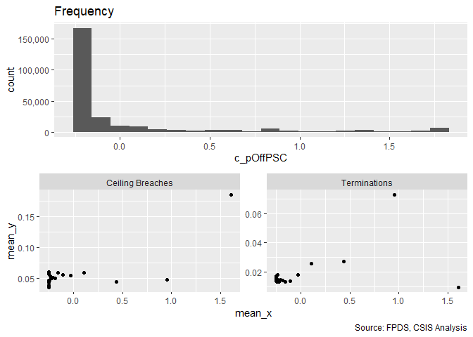

```r
 # !is.na(def_serv$cl_US6_avg_sal_lag1)&
 #  !is.na(def_serv$cl_CFTE)&
 #  !is.na(def_serv$c_pPBSC)&
 #  !is.na(def_serv$c_pOffPSC)&
 #  !is.na(def_serv$c_pairHist)&
 #  !is.na(def_serv$cl_pairCA)&

summary_continuous_plot(serv_smp,"c_pOffPSC")
```

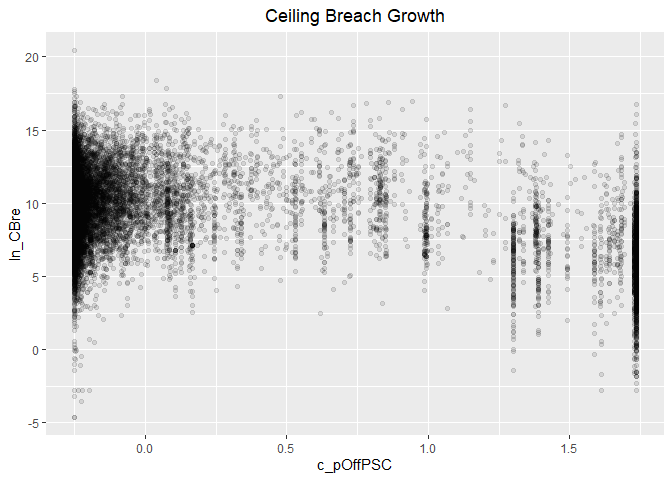

```r
#Scatter Plot
ggplot(serv_smp, aes(x=c_pOffPSC, y=ln_CBre)) + geom_point(alpha = 0.1) + ggtitle('Ceiling Breach Growth') + theme(plot.title = element_text(hjust = 0.5))
```

```r
#Model
b_CBre02B <- glm (data=serv_smp,
                 b_CBre ~ c_pOffPSC, family=binomial(link="logit"))
display(b_CBre02B)
```

```
## glm(formula = b_CBre ~ c_pOffPSC, family = binomial(link = "logit"),
##     data = serv_smp)
##             coef.est coef.se
## (Intercept) -2.87     0.01
## c_pOffPSC    0.69     0.01
## ---
##   n = 250000, k = 2
##   residual deviance = 106149.5, null deviance = 108365.4 (difference = 2215.9)
```

```r
n_CBre02B <- glm(data=serv_smp,
                        ln_CBre ~ c_pOffPSC)

display(n_CBre02B)
```

```
## glm(formula = ln_CBre ~ c_pOffPSC, data = serv_smp)
##             coef.est coef.se
## (Intercept)  9.60     0.02
## c_pOffPSC   -1.62     0.03
## ---
##   n = 15018, k = 2
##   residual deviance = 93313.1, null deviance = 114568.9 (difference = 21255.8)
##   overdispersion parameter = 6.2
##   residual sd is sqrt(overdispersion) = 2.49
```

```r
#Plot residuals versus fitted
stargazer::stargazer(b_CBre01C,b_CBre02A,b_CBre02B,
                       n_CBre01C,n_CBre02A,n_CBre02B,
                       type="text",
                       digits=2)
```

```
##
## ==========================================================================================
##                                                 Dependent variable:
##                          -----------------------------------------------------------------
##                                       b_CBre                          ln_CBre
##                                      logistic                          normal
##                             (1)        (2)        (3)        (4)        (5)        (6)
## ------------------------------------------------------------------------------------------
## cl_US6_avg_sal_lag1Const  0.16***                          0.30***
##                            (0.02)                           (0.06)
##
## cl_CFTE                   0.13***                          1.10***
##                            (0.02)                           (0.05)
##
## c_pPBSC                              0.15***                          -1.90***
##                                       (0.02)                           (0.04)
##
## c_pOffPSC                                       0.69***                          -1.62***
##                                                  (0.01)                           (0.03)
##
## Constant                  -2.83***   -2.82***   -2.87***   9.19***    9.33***    9.60***
##                            (0.01)     (0.01)     (0.01)     (0.02)     (0.02)     (0.02)
##
## ------------------------------------------------------------------------------------------
## Observations              250,000    250,000    250,000     15,018     15,018     15,018
## Log Likelihood           -54,086.50 -54,142.39 -53,074.74 -36,238.38 -35,243.81 -35,027.39
## Akaike Inf. Crit.        108,179.00 108,288.80 106,153.50 72,482.76  70,491.63  70,058.78
## ==========================================================================================
## Note:                                                          *p<0.1; **p<0.05; ***p<0.01
```

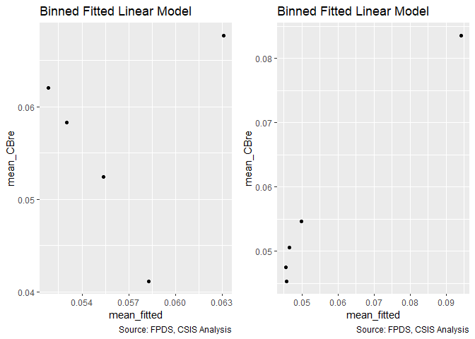

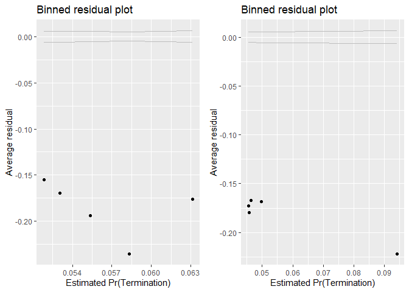

```r
summary_residual_compare(b_CBre02A,b_CBre02B, skip_vif = TRUE)
```

When considering number of contracting office obligations for a given service alone, we find a positive relationship between size of share of contracting office obligations for a service and the likelihood of a ceiling breach, the opposite of what was expected. However, a negative relationship is found, as expected, between the size of the share of contracting office obligations for a service and the overall magnitude of ceiling breaches,

### 02C: Office Capacity

Expectation: Collectively, the larger share of PBSC and contracting office obligations for a given service, the less risk of ceiling breaches and terminations and the more exercised options there would be. Also we expect the results of combined model would be the same as two individual models above.

```r
#Model
b_CBre02C <- glm (data=serv_smp,
                 b_CBre ~ c_pPBSC+c_pOffPSC, family=binomial(link="logit"))
glmer_examine(b_CBre02C)
```

```
##   c_pPBSC c_pOffPSC
##  1.239622  1.239622
```

```r
n_CBre02C <- glm(data=serv_smp,
                        ln_CBre ~ c_pPBSC+c_pOffPSC)

glmer_examine(n_CBre02C)
```

```
##   c_pPBSC c_pOffPSC
##  2.124457  2.124457
```

```r
#Plot residuals versus fitted
stargazer::stargazer(b_CBre01C,b_CBre02A,b_CBre02B,b_CBre02C,

                       n_CBre01C,n_CBre02A,n_CBre02B,n_CBre02C,
                       type="text",
                       digits=2)
```

```
##
## ================================================================================================================
##                                                            Dependent variable:
##                          ---------------------------------------------------------------------------------------
##                                            b_CBre                                      ln_CBre
##                                           logistic                                     normal
##                             (1)        (2)        (3)        (4)        (5)        (6)        (7)        (8)
## ----------------------------------------------------------------------------------------------------------------
## cl_US6_avg_sal_lag1Const  0.16***                                     0.30***
##                            (0.02)                                      (0.06)
##
## cl_CFTE                   0.13***                                     1.10***
##                            (0.02)                                      (0.05)
##
## c_pPBSC                              0.15***               -0.20***              -1.90***              -0.89***
##                                       (0.02)                (0.02)                (0.04)                (0.05)
##
## c_pOffPSC                                       0.69***    0.76***                          -1.62***   -1.11***
##                                                  (0.01)     (0.02)                           (0.03)     (0.04)
##
## Constant                  -2.83***   -2.82***   -2.87***   -2.87***   9.19***    9.33***    9.60***    9.53***
##                            (0.01)     (0.01)     (0.01)     (0.01)     (0.02)     (0.02)     (0.02)     (0.02)
##
## ----------------------------------------------------------------------------------------------------------------
## Observations              250,000    250,000    250,000    250,000     15,018     15,018     15,018     15,018
## Log Likelihood           -54,086.50 -54,142.39 -53,074.74 -53,015.30 -36,238.38 -35,243.81 -35,027.39 -34,871.45
## Akaike Inf. Crit.        108,179.00 108,288.80 106,153.50 106,036.60 72,482.76  70,491.63  70,058.78  69,748.89
## ================================================================================================================
## Note:                                                                                *p<0.1; **p<0.05; ***p<0.01
```

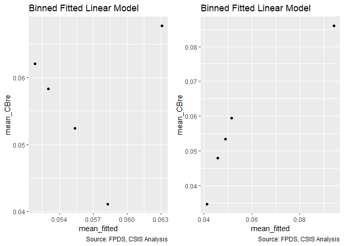

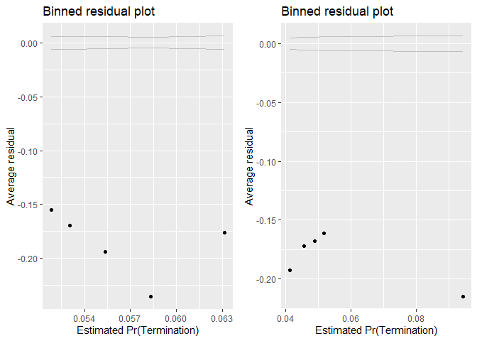

```
## [[1]]
##        model deviance null.deviance difference
## 1 model1_old 108284.8      108365.4   80.58542
## 2 model1_new 106030.6      108365.4 2334.76041
##
## [[2]]
##   c_pPBSC c_pOffPSC
##  1.239622  1.239622
```

```r
summary_residual_compare(b_CBre02A,b_CBre02C)
```

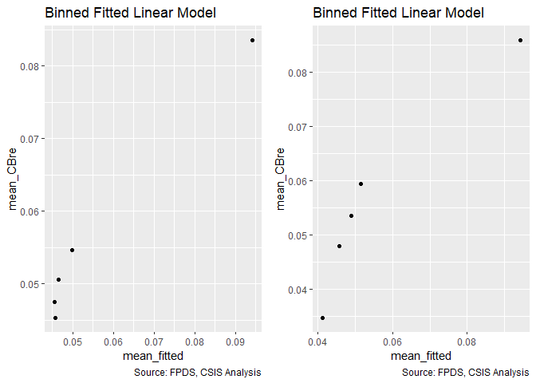

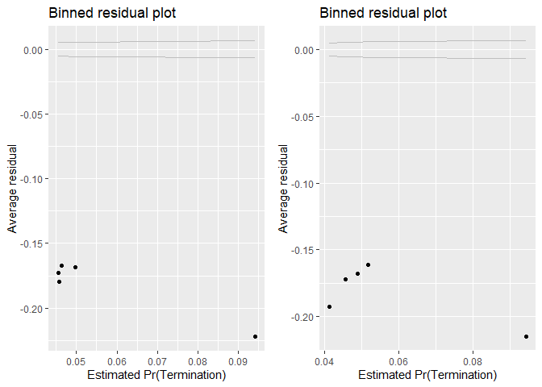

```
## [[1]]
##        model deviance null.deviance difference
## 1 model1_old 106149.5      108365.4   2215.881
## 2 model1_new 106030.6      108365.4   2334.760
##
## [[2]]
##   c_pPBSC c_pOffPSC
##  1.239622  1.239622
```

```r
summary_residual_compare(b_CBre02B,b_CBre02C)
```

No high correlation is observed between PBSC and Contract Office Obligations for PSC based on the vif score.

After combining PBSC and Contract office obligations for PSC, PBSC had a flipped relationship with ceiling breaches that matches with expectation (A look at summary statistics for Performance-Based experience did find that as the percent of performance-based service went from 0 percent to 75 percent, the ceiling breach rate declined. Above 75 percent, it rose dramatically, suggesting an additional variable may influence that relationship.) but lost significance with terminations. Contract office obligations for PSC is associate with more exercised options. The rest of results remained unmatching with expectations.

### 02D: Cumulative Model

Expectation: When all the four variables are combined into one model, same expectations are applied as individual ones. Per service complexity indicator increases, higher risk of ceiling breaches and terminations and less exercised options expected. Per office capacity indicator increases, lower risk of ceiling breaches and terminations and more exercised options expected.

```r
#Model
b_CBre02D <- glm (data=serv_smp,
                 b_CBre ~ cl_US6_avg_sal_lag1Const + cl_CFTE+ c_pPBSC+c_pOffPSC, family=binomial(link="logit"))
glmer_examine(b_CBre02D)
```

```
## cl_US6_avg_sal_lag1Const                  cl_CFTE                  c_pPBSC
##                 1.192884                 1.157327                 1.253342
##                c_pOffPSC
##                 1.248722
```

```r
n_CBre02D <- glm(data=serv_smp,
                        ln_CBre ~ cl_US6_avg_sal_lag1Const + cl_CFTE+ c_pPBSC+c_pOffPSC)

glmer_examine(n_CBre02D)
```

```
## cl_US6_avg_sal_lag1Const                  cl_CFTE                  c_pPBSC
##                 1.249966                 1.222432                 2.124621
##                c_pOffPSC
##                 2.202235
```

```r
#Plot residuals versus fitted
stargazer::stargazer(b_CBre01C,b_CBre02C,b_CBre02D,

                       n_CBre01C,n_CBre02C,n_CBre02D,
                       type="text",
                       digits=2)
```

```
##
## ==========================================================================================
##                                                 Dependent variable:
##                          -----------------------------------------------------------------
##                                       b_CBre                          ln_CBre
##                                      logistic                          normal
##                             (1)        (2)        (3)        (4)        (5)        (6)
## ------------------------------------------------------------------------------------------
## cl_US6_avg_sal_lag1Const  0.16***                0.05**    0.30***               1.14***
##                            (0.02)                (0.02)     (0.06)                (0.05)
##
## cl_CFTE                   0.13***               0.17***    1.10***               0.51***
##                            (0.02)                (0.02)     (0.05)                (0.05)
##
## c_pPBSC                              -0.20***   -0.21***              -0.89***   -0.90***
##                                       (0.02)     (0.02)                (0.05)     (0.05)
##
## c_pOffPSC                            0.76***    0.76***               -1.11***   -1.18***
##                                       (0.02)     (0.02)                (0.04)     (0.04)
##
## Constant                  -2.83***   -2.87***   -2.88***   9.19***    9.53***    9.46***
##                            (0.01)     (0.01)     (0.01)     (0.02)     (0.02)     (0.02)
##
## ------------------------------------------------------------------------------------------
## Observations              250,000    250,000    250,000     15,018     15,018     15,018
## Log Likelihood           -54,086.50 -53,015.30 -52,956.57 -36,238.38 -34,871.45 -34,421.06
## Akaike Inf. Crit.        108,179.00 106,036.60 105,923.10 72,482.76  69,748.89  68,852.12
## ==========================================================================================
## Note:                                                          *p<0.1; **p<0.05; ***p<0.01
```

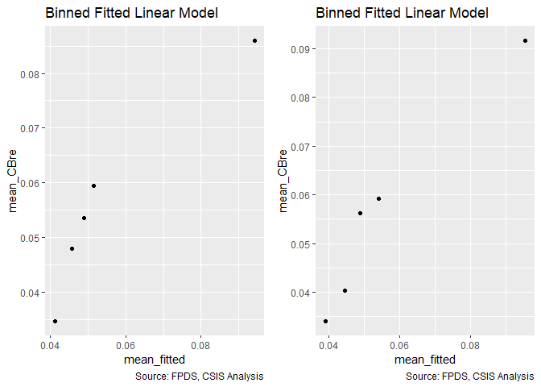

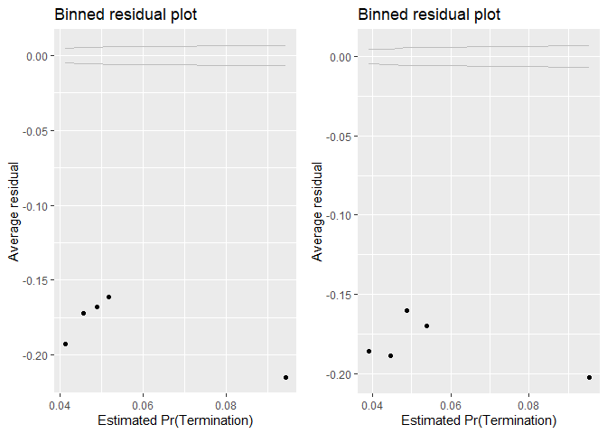

```
## [[1]]
##        model deviance null.deviance difference
## 1 model1_old 106030.6      108365.4   2334.760
## 2 model1_new 105913.1      108365.4   2452.226
##
## [[2]]
## cl_US6_avg_sal_lag1Const                  cl_CFTE                  c_pPBSC
##                 1.192884                 1.157327                 1.253342
##                c_pOffPSC
##                 1.248722
```

```r
summary_residual_compare(b_CBre02C,b_CBre02D)
```

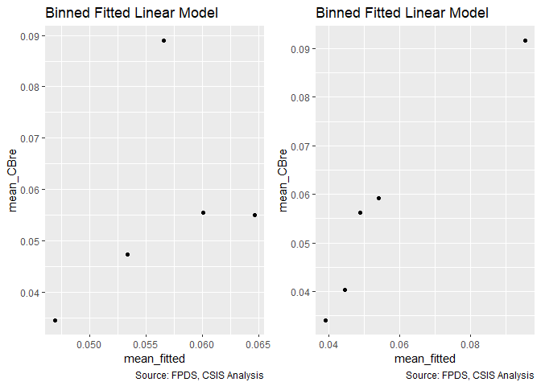

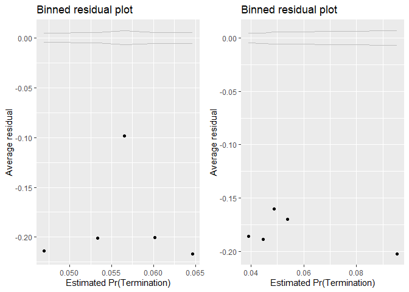

```
## [[1]]
##        model deviance null.deviance difference
## 1 model1_old 108173.0      108365.4   192.3502
## 2 model1_new 105913.1      108365.4  2452.2259
##
## [[2]]
## cl_US6_avg_sal_lag1Const                  cl_CFTE                  c_pPBSC
##                 1.192884                 1.157327                 1.253342
##                c_pOffPSC
##                 1.248722
```

```r
summary_residual_compare(b_CBre01C,b_CBre02D)
```

No high correlation is observed among all of the 4 predictors (average salary, invoiced rate, PBSC and Contract Office Obligations for PSC) so far based on the vif score. When all measures for sevice complexity and office capacity are combined, per dependent variable:

1. Ceiling Breaches: All variables remain the same within each subgroup (Services Complexity and Office Capacity). Except for Contract office obligations for PSC, the results of other varibles matched with the expectation for ceiling breaches so far.
2. Terminations: Except for Contract office obligations for PSC, the rest of variables didn’t show significant relationships with Termination. The only significant relationship between Contract office obligations for PSC and Temrination didn’t match the expectation.
3. Exercised Options: Except for PBSC, all other three variables are associated with exercised options as expected.

## Office-Vendor Relationship

### 03A: Pair History

Expactation: The number of past years of the relationship between the contracting office or the contractors with a single transaction in a given fiscal year enough to qualify, namely, pair history increases (decreases), the likelihood of cost ceiling breaches and terminations decreases (increases) and the exercised options increase (decrease) for that partnership.

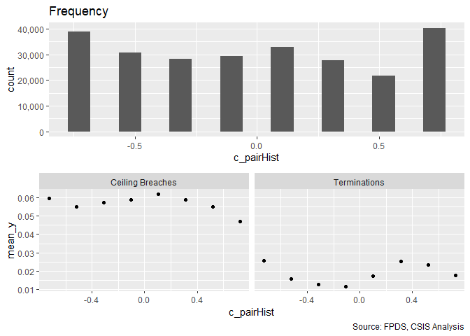

```
## [[1]]
##
## -0.727331277356926 -0.519773791968938  -0.31221630658095
##              38828              30765              28278
## -0.104658821192962  0.102898664195026  0.310456149583014
##              29388              33009              27626
##  0.518013634971002   0.72557112035899
##              21649              40457
##
## [[2]]
##
##                       None Ceiling Breach
##   -0.727331277356926 36516           2312
##   -0.519773791968938 29081           1684
##   -0.31221630658095  26660           1618
##   -0.104658821192962 27666           1722
##   0.102898664195026  30972           2037
##   0.310456149583014  26001           1625
##   0.518013634971002  20460           1189
##   0.72557112035899   38563           1894
##
## [[3]]
##
##                          0     1
##   -0.727331277356926 37822  1006
##   -0.519773791968938 30282   483
##   -0.31221630658095  27913   365
##   -0.104658821192962 29045   343
##   0.102898664195026  32433   576
##   0.310456149583014  26922   704
##   0.518013634971002  21142   507
##   0.72557112035899   39736   721
```

```r
 # !is.na(def_serv$cl_US6_avg_sal_lag1)&
 #  !is.na(def_serv$cl_CFTE)&
 #  !is.na(def_serv$c_pPBSC)&
 #  !is.na(def_serv$c_pOffPSC)&
 #  !is.na(def_serv$c_pairHist)&
 #  !is.na(def_serv$cl_pairCA)&

summary_discrete_plot(serv_smp,"c_pairHist")
```

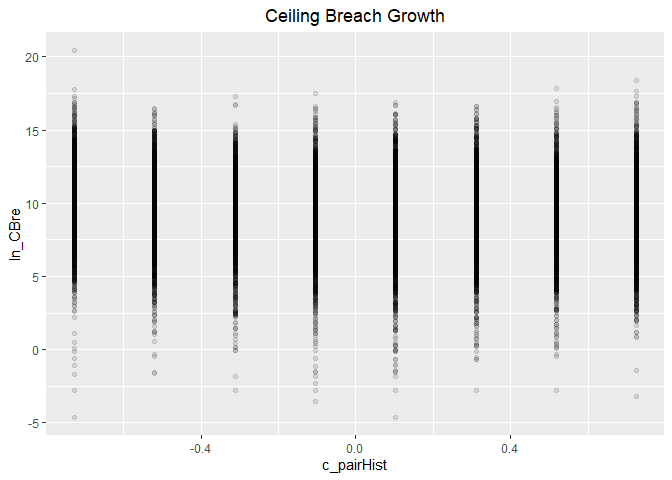

```r
#Scatter Plot
ggplot(serv_smp, aes(x=c_pairHist, y=ln_CBre)) + geom_point(alpha = 0.1) + ggtitle('Ceiling Breach Growth') + theme(plot.title = element_text(hjust = 0.5))
```

```r
#Model
b_CBre03A <- glm (data=serv_smp,
                 b_CBre ~ c_pairHist, family=binomial(link="logit"))
display(b_CBre03A)
```

```
## glm(formula = b_CBre ~ c_pairHist, family = binomial(link = "logit"),
##     data = serv_smp)
##             coef.est coef.se
## (Intercept) -2.82     0.01
## c_pairHist  -0.10     0.02
## ---
##   n = 250000, k = 2
##   residual deviance = 108331.1, null deviance = 108365.4 (difference = 34.2)
```

```r
n_CBre03A <- glm(data=serv_smp,
                        ln_CBre ~ c_pairHist)

display(n_CBre03A)
```

```
## glm(formula = ln_CBre ~ c_pairHist, data = serv_smp)
##             coef.est coef.se
## (Intercept)  9.23     0.02
## c_pairHist  -0.59     0.05
## ---
##   n = 15018, k = 2
##   residual deviance = 113349.6, null deviance = 114568.9 (difference = 1219.3)
##   overdispersion parameter = 7.5
##   residual sd is sqrt(overdispersion) = 2.75
```

```r
#Plot residuals versus fitted
  stargazer::stargazer(b_CBre02D,b_CBre03A,

                       n_CBre02D,n_CBre03A,
                       type="text",
                       digits=2)
```

```
##
## ====================================================================
##                                      Dependent variable:
##                          -------------------------------------------
##                                 b_CBre                ln_CBre
##                                logistic               normal
##                             (1)        (2)        (3)        (4)
## --------------------------------------------------------------------
## cl_US6_avg_sal_lag1Const   0.05**               1.14***
##                            (0.02)                (0.05)
##
## cl_CFTE                   0.17***               0.51***
##                            (0.02)                (0.05)
##
## c_pPBSC                   -0.21***              -0.90***
##                            (0.02)                (0.05)
##
## c_pOffPSC                 0.76***               -1.18***
##                            (0.02)                (0.04)
##
## c_pairHist                           -0.10***              -0.59***
##                                       (0.02)                (0.05)
##
## Constant                  -2.88***   -2.82***   9.46***    9.23***
##                            (0.01)     (0.01)     (0.02)     (0.02)
##
## --------------------------------------------------------------------
## Observations              250,000    250,000     15,018     15,018
## Log Likelihood           -52,956.57 -54,165.57 -34,421.06 -36,488.01
## Akaike Inf. Crit.        105,923.10 108,335.10 68,852.12  72,980.03
## ====================================================================
## Note:                                    *p<0.1; **p<0.05; ***p<0.01
```

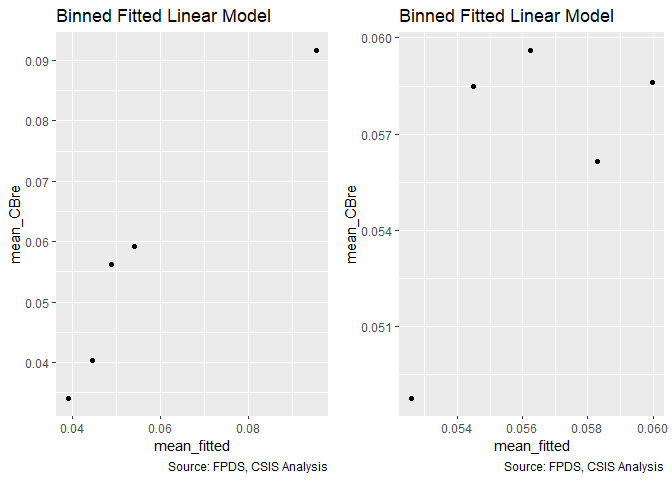

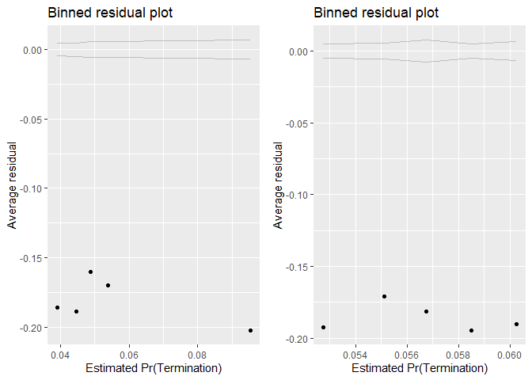

```r
summary_residual_compare(b_CBre02D,b_CBre03A, skip_vif = TRUE)
```

When considering pair history alone, expectations were met for ceiling breaches and terminations, but not for exercised options.